# Risk Factor Analysis

## Outcome Variable

**Outcome Variable:** y_rate_len

## Predictor Variables

**Intervention Variable:** parity

**Adjustment Set:**

unadjusted

## Stratifying Variables

The analysis was stratified on these variable(s):

- agecat
- studyid
- country

## Data Summary

| agecat | studyid | country | parity | n_cell | n |
| --- | --- | --- | --- | --- | --- |
| 0-3 months | ki1000304b-SAS-CompFeed | INDIA | 1 | 313 | 1168 |
| 0-3 months | ki1000304b-SAS-CompFeed | INDIA | 2 | 280 | 1168 |
| 0-3 months | ki1000304b-SAS-CompFeed | INDIA | 3+ | 575 | 1168 |
| 0-3 months | ki1017093b-PROVIDE | BANGLADESH | 1 | 240 | 634 |
| 0-3 months | ki1017093b-PROVIDE | BANGLADESH | 2 | 225 | 634 |
| 0-3 months | ki1017093b-PROVIDE | BANGLADESH | 3+ | 169 | 634 |
| 0-3 months | ki1101329-Keneba | GAMBIA | 1 | 130 | 1145 |
| 0-3 months | ki1101329-Keneba | GAMBIA | 2 | 113 | 1145 |
| 0-3 months | ki1101329-Keneba | GAMBIA | 3+ | 902 | 1145 |
| 0-3 months | ki1126311-ZVITAMBO | ZIMBABWE | 1 | 3052 | 7863 |
| 0-3 months | ki1126311-ZVITAMBO | ZIMBABWE | 2 | 2438 | 7863 |
| 0-3 months | ki1126311-ZVITAMBO | ZIMBABWE | 3+ | 2373 | 7863 |
| 0-3 months | ki1135781-COHORTS | GUATEMALA | 1 | 93 | 728 |
| 0-3 months | ki1135781-COHORTS | GUATEMALA | 2 | 111 | 728 |
| 0-3 months | ki1135781-COHORTS | GUATEMALA | 3+ | 524 | 728 |
| 0-3 months | ki1135781-COHORTS | INDIA | 1 | 671 | 4021 |
| 0-3 months | ki1135781-COHORTS | INDIA | 2 | 1015 | 4021 |
| 0-3 months | ki1135781-COHORTS | INDIA | 3+ | 2335 | 4021 |
| 0-3 months | kiGH5241-JiVitA-3 | BANGLADESH | 1 | 12750 | 40056 |
| 0-3 months | kiGH5241-JiVitA-3 | BANGLADESH | 2 | 13890 | 40056 |
| 0-3 months | kiGH5241-JiVitA-3 | BANGLADESH | 3+ | 13416 | 40056 |
| 3-6 months | ki1000304b-SAS-CompFeed | INDIA | 1 | 299 | 1124 |
| 3-6 months | ki1000304b-SAS-CompFeed | INDIA | 2 | 261 | 1124 |
| 3-6 months | ki1000304b-SAS-CompFeed | INDIA | 3+ | 564 | 1124 |
| 3-6 months | ki1017093b-PROVIDE | BANGLADESH | 1 | 206 | 574 |
| 3-6 months | ki1017093b-PROVIDE | BANGLADESH | 2 | 211 | 574 |
| 3-6 months | ki1017093b-PROVIDE | BANGLADESH | 3+ | 157 | 574 |
| 3-6 months | ki1066203-TanzaniaChild2 | TANZANIA, UNITED REPUBLIC OF | 1 | 566 | 1637 |
| 3-6 months | ki1066203-TanzaniaChild2 | TANZANIA, UNITED REPUBLIC OF | 2 | 536 | 1637 |
| 3-6 months | ki1066203-TanzaniaChild2 | TANZANIA, UNITED REPUBLIC OF | 3+ | 535 | 1637 |

[output cut: 78 more lines]

The following strata were considered:

- agecat: 0-3 months, studyid: ki1000304b-SAS-CompFeed, country: INDIA
- agecat: 0-3 months, studyid: ki1017093b-PROVIDE, country: BANGLADESH
- agecat: 0-3 months, studyid: ki1101329-Keneba, country: GAMBIA
- agecat: 0-3 months, studyid: ki1126311-ZVITAMBO, country: ZIMBABWE
- agecat: 0-3 months, studyid: ki1135781-COHORTS, country: GUATEMALA
- agecat: 0-3 months, studyid: ki1135781-COHORTS, country: INDIA
- agecat: 0-3 months, studyid: kiGH5241-JiVitA-3, country: BANGLADESH
- agecat: 12-24 months, studyid: ki1017093b-PROVIDE, country: BANGLADESH
- agecat: 12-24 months, studyid: ki1066203-TanzaniaChild2, country: TANZANIA, UNITED REPUBLIC OF
- agecat: 12-24 months, studyid: ki1101329-Keneba, country: GAMBIA
- agecat: 12-24 months, studyid: ki1113344-GMS-Nepal, country: NEPAL
- agecat: 12-24 months, studyid: ki1126311-ZVITAMBO, country: ZIMBABWE
- agecat: 12-24 months, studyid: ki1135781-COHORTS, country: GUATEMALA
- agecat: 12-24 months, studyid: ki1135781-COHORTS, country: INDIA
- agecat: 12-24 months, studyid: ki1135781-COHORTS, country: PHILIPPINES
- agecat: 12-24 months, studyid: kiGH5241-JiVitA-3, country: BANGLADESH
- agecat: 3-6 months, studyid: ki1000304b-SAS-CompFeed, country: INDIA
- agecat: 3-6 months, studyid: ki1017093b-PROVIDE, country: BANGLADESH
- agecat: 3-6 months, studyid: ki1066203-TanzaniaChild2, country: TANZANIA, UNITED REPUBLIC OF
- agecat: 3-6 months, studyid: ki1101329-Keneba, country: GAMBIA
- agecat: 3-6 months, studyid: ki1113344-GMS-Nepal, country: NEPAL
- agecat: 3-6 months, studyid: ki1126311-ZVITAMBO, country: ZIMBABWE
- agecat: 3-6 months, studyid: ki1135781-COHORTS, country: GUATEMALA
- agecat: 3-6 months, studyid: ki1135781-COHORTS, country: INDIA
- agecat: 3-6 months, studyid: kiGH5241-JiVitA-3, country: BANGLADESH
- agecat: 6-12 months, studyid: ki1000304b-SAS-CompFeed, country: INDIA
- agecat: 6-12 months, studyid: ki1000304b-SAS-FoodSuppl, country: INDIA
- agecat: 6-12 months, studyid: ki1017093b-PROVIDE, country: BANGLADESH
- agecat: 6-12 months, studyid: ki1066203-TanzaniaChild2, country: TANZANIA, UNITED REPUBLIC OF
- agecat: 6-12 months, studyid: ki1101329-Keneba, country: GAMBIA
- agecat: 6-12 months, studyid: ki1113344-GMS-Nepal, country: NEPAL
- agecat: 6-12 months, studyid: ki1126311-ZVITAMBO, country: ZIMBABWE
- agecat: 6-12 months, studyid: ki1135781-COHORTS, country: GUATEMALA
- agecat: 6-12 months, studyid: ki1135781-COHORTS, country: INDIA
- agecat: 6-12 months, studyid: ki1135781-COHORTS, country: PHILIPPINES
- agecat: 6-12 months, studyid: kiGH5241-JiVitA-3, country: BANGLADESH

### Dropped Strata

Some strata were dropped due to rare outcomes:

- agecat: 12-24 months, studyid: ki1066203-TanzaniaChild2, country: TANZANIA, UNITED REPUBLIC OF

## Methods Detail

We’re interested in the causal parameters $E[Y_a]$ for all values of $a \in \mathcal{A}$. These parameters represent the mean outcome if, possibly contrary to fact, we intervened to set all units to have $A=a$. Under the randomization and positivity assumptions, these are identified by the statistical parameters $\psi_a=E_W[E_{Y|A,W}(Y|A=a,W)]$. In addition, we’re interested in the mean of $Y$, $E[Y]$ under no intervention (the observed mean). We will estimate these parameters by using SuperLearner to fit the relevant likelihood factors – $E_{Y|A,W}(Y|A=a,W)$ and $p(A=a|W)$, and then updating our likelihood fit using a joint TMLE.

For unadjusted analyses ($W=\{\}$), initial likelihoods were estimated using Lrnr_glm to estimate the simple $E(Y|A)$ and Lrnr_mean to estimate $p(A)$. For adjusted analyses, a small library containing Lrnr_glmnet, Lrnr_xgboost, and Lrnr_mean was used.

Having estimated these parameters, we will then use the delta method to estimate relative risks and attributable risks relative to a prespecified baseline level of $A$.

# Results Detail

## Results Plots

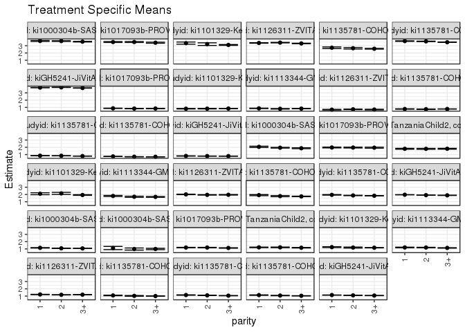

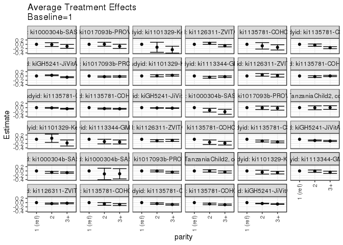

## Results Table

### Parameter: TSM

| agecat | studyid | country | intervention_level | baseline_level | estimate | ci_lower | ci_upper |
| --- | --- | --- | --- | --- | --- | --- | --- |
| 0-3 months | ki1000304b-SAS-CompFeed | INDIA | 1 | NA | 3.6521288 | 3.5867730 | 3.7174847 |
| 0-3 months | ki1000304b-SAS-CompFeed | INDIA | 2 | NA | 3.6386508 | 3.5868776 | 3.6904241 |
| 0-3 months | ki1000304b-SAS-CompFeed | INDIA | 3+ | NA | 3.5568427 | 3.5134444 | 3.6002410 |
| 0-3 months | ki1017093b-PROVIDE | BANGLADESH | 1 | NA | 3.5066649 | 3.4413382 | 3.5719916 |
| 0-3 months | ki1017093b-PROVIDE | BANGLADESH | 2 | NA | 3.5095106 | 3.4448208 | 3.5742005 |
| 0-3 months | ki1017093b-PROVIDE | BANGLADESH | 3+ | NA | 3.4128621 | 3.3391597 | 3.4865644 |
| 0-3 months | ki1101329-Keneba | GAMBIA | 1 | NA | 3.3551092 | 3.2056109 | 3.5046076 |
| 0-3 months | ki1101329-Keneba | GAMBIA | 2 | NA | 3.2179431 | 3.0360112 | 3.3998750 |
| 0-3 months | ki1101329-Keneba | GAMBIA | 3+ | NA | 3.1061436 | 3.0506386 | 3.1616487 |
| 0-3 months | ki1126311-ZVITAMBO | ZIMBABWE | 1 | NA | 3.3757190 | 3.3420748 | 3.4093631 |
| 0-3 months | ki1126311-ZVITAMBO | ZIMBABWE | 2 | NA | 3.4242228 | 3.3876046 | 3.4608410 |
| 0-3 months | ki1126311-ZVITAMBO | ZIMBABWE | 3+ | NA | 3.3090739 | 3.2704183 | 3.3477295 |
| 0-3 months | ki1135781-COHORTS | GUATEMALA | 1 | NA | 2.7247289 | 2.6151088 | 2.8343490 |
| 0-3 months | ki1135781-COHORTS | GUATEMALA | 2 | NA | 2.6528983 | 2.5487508 | 2.7570459 |
| 0-3 months | ki1135781-COHORTS | GUATEMALA | 3+ | NA | 2.5829251 | 2.5300574 | 2.6357927 |
| 0-3 months | ki1135781-COHORTS | INDIA | 1 | NA | 3.6350450 | 3.5942998 | 3.6757902 |
| 0-3 months | ki1135781-COHORTS | INDIA | 2 | NA | 3.5966624 | 3.5625659 | 3.6307589 |
| 0-3 months | ki1135781-COHORTS | INDIA | 3+ | NA | 3.4777223 | 3.4528365 | 3.5026081 |
| 0-3 months | kiGH5241-JiVitA-3 | BANGLADESH | 1 | NA | 3.7270748 | 3.7108177 | 3.7433319 |
| 0-3 months | kiGH5241-JiVitA-3 | BANGLADESH | 2 | NA | 3.7585439 | 3.7431357 | 3.7739521 |
| 0-3 months | kiGH5241-JiVitA-3 | BANGLADESH | 3+ | NA | 3.6688155 | 3.6530925 | 3.6845385 |
| 3-6 months | ki1000304b-SAS-CompFeed | INDIA | 1 | NA | 2.0650463 | 1.9789638 | 2.1511288 |
| 3-6 months | ki1000304b-SAS-CompFeed | INDIA | 2 | NA | 1.9447541 | 1.8958040 | 1.9937043 |
| 3-6 months | ki1000304b-SAS-CompFeed | INDIA | 3+ | NA | 1.8727868 | 1.8115410 | 1.9340327 |
| 3-6 months | ki1017093b-PROVIDE | BANGLADESH | 1 | NA | 1.9755799 | 1.9201348 | 2.0310250 |
| 3-6 months | ki1017093b-PROVIDE | BANGLADESH | 2 | NA | 1.9669904 | 1.9087430 | 2.0252379 |
| 3-6 months | ki1017093b-PROVIDE | BANGLADESH | 3+ | NA | 1.9500715 | 1.8793189 | 2.0208240 |
| 3-6 months | ki1066203-TanzaniaChild2 | TANZANIA, UNITED REPUBLIC OF | 1 | NA | 1.7978869 | 1.7361658 | 1.8596080 |
| 3-6 months | ki1066203-TanzaniaChild2 | TANZANIA, UNITED REPUBLIC OF | 2 | NA | 1.7899300 | 1.7237339 | 1.8561261 |
| 3-6 months | ki1066203-TanzaniaChild2 | TANZANIA, UNITED REPUBLIC OF | 3+ | NA | 1.8001906 | 1.7410485 | 1.8593327 |

[output cut: 75 more lines]

### Parameter: E(Y)

| agecat | studyid | country | intervention_level | baseline_level | estimate | ci_lower | ci_upper |
| --- | --- | --- | --- | --- | --- | --- | --- |
| 0-3 months | ki1000304b-SAS-CompFeed | INDIA | NA | NA | 3.6019890 | 3.5739652 | 3.6300127 |
| 0-3 months | ki1017093b-PROVIDE | BANGLADESH | NA | NA | 3.4826706 | 3.4434873 | 3.5218539 |
| 0-3 months | ki1101329-Keneba | GAMBIA | NA | NA | 3.1454440 | 3.0949962 | 3.1958917 |
| 0-3 months | ki1126311-ZVITAMBO | ZIMBABWE | NA | NA | 3.3706450 | 3.3497515 | 3.3915385 |
| 0-3 months | ki1135781-COHORTS | GUATEMALA | NA | NA | 2.6117091 | 2.5680119 | 2.6554063 |
| 0-3 months | ki1135781-COHORTS | INDIA | NA | NA | 3.5339988 | 3.5157374 | 3.5522602 |
| 0-3 months | kiGH5241-JiVitA-3 | BANGLADESH | NA | NA | 3.7184743 | 3.7081281 | 3.7288205 |
| 3-6 months | ki1000304b-SAS-CompFeed | INDIA | NA | NA | 1.9406419 | 1.8967379 | 1.9845458 |
| 3-6 months | ki1017093b-PROVIDE | BANGLADESH | NA | NA | 1.9654454 | 1.9303798 | 2.0005110 |
| 3-6 months | ki1066203-TanzaniaChild2 | TANZANIA, UNITED REPUBLIC OF | NA | NA | 1.7960345 | 1.7599951 | 1.8320738 |
| 3-6 months | ki1101329-Keneba | GAMBIA | NA | NA | 1.9715566 | 1.9280386 | 2.0150747 |
| 3-6 months | ki1113344-GMS-Nepal | NEPAL | NA | NA | 1.7057418 | 1.6666784 | 1.7448052 |
| 3-6 months | ki1126311-ZVITAMBO | ZIMBABWE | NA | NA | 1.9747519 | 1.9548124 | 1.9946914 |
| 3-6 months | ki1135781-COHORTS | GUATEMALA | NA | NA | 1.7616932 | 1.7309393 | 1.7924472 |
| 3-6 months | ki1135781-COHORTS | INDIA | NA | NA | 1.8562696 | 1.8412447 | 1.8712944 |
| 3-6 months | kiGH5241-JiVitA-3 | BANGLADESH | NA | NA | 1.9201827 | 1.9097195 | 1.9306459 |
| 6-12 months | ki1000304b-SAS-CompFeed | INDIA | NA | NA | 1.0983052 | 1.0864567 | 1.1101538 |
| 6-12 months | ki1000304b-SAS-FoodSuppl | INDIA | NA | NA | 1.0139672 | 0.9374673 | 1.0904670 |
| 6-12 months | ki1017093b-PROVIDE | BANGLADESH | NA | NA | 1.1731762 | 1.1558671 | 1.1904853 |
| 6-12 months | ki1066203-TanzaniaChild2 | TANZANIA, UNITED REPUBLIC OF | NA | NA | 1.1974328 | 1.1756681 | 1.2191974 |
| 6-12 months | ki1101329-Keneba | GAMBIA | NA | NA | 1.1774049 | 1.1574133 | 1.1973966 |
| 6-12 months | ki1113344-GMS-Nepal | NEPAL | NA | NA | 1.1681560 | 1.1485303 | 1.1877817 |
| 6-12 months | ki1126311-ZVITAMBO | ZIMBABWE | NA | NA | 1.1980958 | 1.1871818 | 1.2090098 |
| 6-12 months | ki1135781-COHORTS | GUATEMALA | NA | NA | 1.0185507 | 1.0014002 | 1.0357013 |
| 6-12 months | ki1135781-COHORTS | INDIA | NA | NA | 1.0842179 | 1.0737055 | 1.0947303 |
| 6-12 months | ki1135781-COHORTS | PHILIPPINES | NA | NA | 1.0674471 | 1.0552459 | 1.0796483 |
| 6-12 months | kiGH5241-JiVitA-3 | BANGLADESH | NA | NA | 1.1069007 | 1.1001595 | 1.1136418 |
| 12-24 months | ki1017093b-PROVIDE | BANGLADESH | NA | NA | 0.8575519 | 0.8455586 | 0.8695452 |
| 12-24 months | ki1101329-Keneba | GAMBIA | NA | NA | 0.8449409 | 0.8333460 | 0.8565357 |
| 12-24 months | ki1113344-GMS-Nepal | NEPAL | NA | NA | 0.8378848 | 0.8224521 | 0.8533174 |
| 12-24 months | ki1126311-ZVITAMBO | ZIMBABWE | NA | NA | 0.7099126 | 0.6840087 | 0.7358165 |
| 12-24 months | ki1135781-COHORTS | GUATEMALA | NA | NA | 0.7793681 | 0.7685580 | 0.7901783 |
| 12-24 months | ki1135781-COHORTS | INDIA | NA | NA | 0.8139538 | 0.8077496 | 0.8201580 |
| 12-24 months | ki1135781-COHORTS | PHILIPPINES | NA | NA | 0.7067500 | 0.6994129 | 0.7140870 |
| 12-24 months | kiGH5241-JiVitA-3 | BANGLADESH | NA | NA | 0.7966099 | 0.7912995 | 0.8019202 |

### Parameter: ATE

| agecat | studyid | country | intervention_level | baseline_level | estimate | ci_lower | ci_upper |
| --- | --- | --- | --- | --- | --- | --- | --- |
| 0-3 months | ki1000304b-SAS-CompFeed | INDIA | 1 | 1 | 0.0000000 | 0.0000000 | 0.0000000 |
| 0-3 months | ki1000304b-SAS-CompFeed | INDIA | 2 | 1 | -0.0134780 | -0.1036582 | 0.0767023 |
| 0-3 months | ki1000304b-SAS-CompFeed | INDIA | 3+ | 1 | -0.0952861 | -0.1864274 | -0.0041448 |
| 0-3 months | ki1017093b-PROVIDE | BANGLADESH | 1 | 1 | 0.0000000 | 0.0000000 | 0.0000000 |
| 0-3 months | ki1017093b-PROVIDE | BANGLADESH | 2 | 1 | 0.0028457 | -0.0890910 | 0.0947824 |
| 0-3 months | ki1017093b-PROVIDE | BANGLADESH | 3+ | 1 | -0.0938029 | -0.1922895 | 0.0046838 |
| 0-3 months | ki1101329-Keneba | GAMBIA | 1 | 1 | 0.0000000 | 0.0000000 | 0.0000000 |
| 0-3 months | ki1101329-Keneba | GAMBIA | 2 | 1 | -0.1371661 | -0.3726422 | 0.0983100 |
| 0-3 months | ki1101329-Keneba | GAMBIA | 3+ | 1 | -0.2489656 | -0.4084352 | -0.0894959 |
| 0-3 months | ki1126311-ZVITAMBO | ZIMBABWE | 1 | 1 | 0.0000000 | 0.0000000 | 0.0000000 |
| 0-3 months | ki1126311-ZVITAMBO | ZIMBABWE | 2 | 1 | 0.0485038 | -0.0012236 | 0.0982313 |
| 0-3 months | ki1126311-ZVITAMBO | ZIMBABWE | 3+ | 1 | -0.0666451 | -0.1178913 | -0.0153988 |
| 0-3 months | ki1135781-COHORTS | GUATEMALA | 1 | 1 | 0.0000000 | 0.0000000 | 0.0000000 |
| 0-3 months | ki1135781-COHORTS | GUATEMALA | 2 | 1 | -0.0718306 | -0.2230366 | 0.0793755 |
| 0-3 months | ki1135781-COHORTS | GUATEMALA | 3+ | 1 | -0.1418038 | -0.2635065 | -0.0201012 |
| 0-3 months | ki1135781-COHORTS | INDIA | 1 | 1 | 0.0000000 | 0.0000000 | 0.0000000 |
| 0-3 months | ki1135781-COHORTS | INDIA | 2 | 1 | -0.0383826 | -0.0915121 | 0.0147469 |
| 0-3 months | ki1135781-COHORTS | INDIA | 3+ | 1 | -0.1573227 | -0.2050665 | -0.1095788 |
| 0-3 months | kiGH5241-JiVitA-3 | BANGLADESH | 1 | 1 | 0.0000000 | 0.0000000 | 0.0000000 |
| 0-3 months | kiGH5241-JiVitA-3 | BANGLADESH | 2 | 1 | 0.0314691 | 0.0110156 | 0.0519226 |
| 0-3 months | kiGH5241-JiVitA-3 | BANGLADESH | 3+ | 1 | -0.0582593 | -0.0796011 | -0.0369176 |
| 3-6 months | ki1000304b-SAS-CompFeed | INDIA | 1 | 1 | 0.0000000 | 0.0000000 | 0.0000000 |
| 3-6 months | ki1000304b-SAS-CompFeed | INDIA | 2 | 1 | -0.1202921 | -0.2073000 | -0.0332843 |
| 3-6 months | ki1000304b-SAS-CompFeed | INDIA | 3+ | 1 | -0.1922594 | -0.3082162 | -0.0763027 |
| 3-6 months | ki1017093b-PROVIDE | BANGLADESH | 1 | 1 | 0.0000000 | 0.0000000 | 0.0000000 |
| 3-6 months | ki1017093b-PROVIDE | BANGLADESH | 2 | 1 | -0.0085894 | -0.0890066 | 0.0718277 |
| 3-6 months | ki1017093b-PROVIDE | BANGLADESH | 3+ | 1 | -0.0255084 | -0.1153977 | 0.0643808 |
| 3-6 months | ki1066203-TanzaniaChild2 | TANZANIA, UNITED REPUBLIC OF | 1 | 1 | 0.0000000 | 0.0000000 | 0.0000000 |
| 3-6 months | ki1066203-TanzaniaChild2 | TANZANIA, UNITED REPUBLIC OF | 2 | 1 | -0.0079569 | -0.0984633 | 0.0825496 |
| 3-6 months | ki1066203-TanzaniaChild2 | TANZANIA, UNITED REPUBLIC OF | 3+ | 1 | 0.0023037 | -0.0831789 | 0.0877864 |

[output cut: 75 more lines]